# Machine Learning

# Agenda

- `pyspark.ml`
- Case: Prediction of Real Estate Prices

### The Supervised Learning Problem

Standard working assumption in supervised learning is that the mechanish that generates the data can be desribed as

$$ \begin{aligned} Y &= f(X) + \epsilon \quad \text{[Regression]} \\ P(Y = 1| X) &= f(X) \quad \text{[Classification]} \end{aligned} $$

$f$ is a function, $X=(X_1,X_2,\dots,X_p)$ is a vector of inputs/features, $Y$ is the labels/output/response and $\epsilon$ is random noise.

[figure not shown]

#### General Problem:

We are interested in estimating the function $f$ using a dataset consisting of labels: $Y$ and features: $X$, that are generated by the same mechanish described above.

## Machine Learning

Creating a `pyspark.ml` model is very similar to the standard sklearn API but there are some differences.

1. You can specify the subset of input features in a pipeline.
2. When predicting you use a `.transform()` method on a fitted model object, which adds extra column(s) based on the model.

## Example: Dataset

The `california_housing` dataset contains:

- `MedHouseVal` Median house value for California districts, expressed in hundreds of thousands of dollars ($100,000).
- `MedInc` Median income in block group
- `HouseAge` Median house age in block group
- `AveRooms` Average number of rooms per household
- `AveBedrms` Average number of bedrooms per household
- `Population` Block group population
- `AveOccup` Average number of household members
- `Latitude` Block group latitude
- `Longitude` Block group longitude

```python
california_housing = spark.read.csv("/datasets/california_housing/california_housing.csv", header=True, inferSchema=True)
display(california_housing)
```

|  | MedInc | HouseAge | AveRooms | AveBedrms | Population | AveOccup | Latitude | Longitude | MedHouseVal |
| --- | --- | --- | --- | --- | --- | --- | --- | --- | --- |
| 0 | 8.3252 | 41.0 | 6.984127 | 1.023810 | 322.0 | 2.555556 | 37.88 | -122.23 | 4.526 |
| 1 | 8.3014 | 21.0 | 6.238137 | 0.971880 | 2401.0 | 2.109842 | 37.86 | -122.22 | 3.585 |
| 2 | 7.2574 | 52.0 | 8.288136 | 1.073446 | 496.0 | 2.802260 | 37.85 | -122.24 | 3.521 |
| 3 | 5.6431 | 52.0 | 5.817352 | 1.073059 | 558.0 | 2.547945 | 37.85 | -122.25 | 3.413 |
| 4 | 3.8462 | 52.0 | 6.281853 | 1.081081 | 565.0 | 2.181467 | 37.85 | -122.25 | 3.422 |

## Split

We set a seed for reproducability.

```python
train, test = california_housing.randomSplit([.8, .2], seed=42)
print(f"Size of training dataset {train.count()}")
print(f"Size of testing dataset  {test.count()}")
```

```
Size of training dataset 16560
Size of testing dataset  4080
```

### Classification and Regression Trees (CART)

We choose the variable and split-point to achieve the best fit. Then one or both of these regions are split into two more regions, and this process is continued, until some **stopping rule** is applied.

[figure not shown]

### Fitting a `DecisionTreeRegressor`

```python
from pyspark.ml import Pipeline
from pyspark.ml import feature
from pyspark.ml import regression

# Specify the response variable and the input features.
RESPONSE = 'MedHouseVal'
FEATURES = ['MedInc', 'HouseAge', 'AveRooms', 'AveBedrms', 'Population', 'AveOccup', 'Latitude', 'Longitude']

# Stages in the pipeline
assembler = feature.VectorAssembler(
  inputCols=FEATURES,
  outputCol='features'
)
dt = regression.DecisionTreeRegressor(
    labelCol=RESPONSE,
    maxDepth=3,
    minInstancesPerNode=256,
)
pipeline = Pipeline(stages=[assembler, dt])

# Fit the model to the training data.
model = pipeline.fit(train)
```

### Grid Search

```python
from pyspark.ml import tuning
from pyspark.ml import evaluation

# A seed for the random sampler, used for reproducibility.
SEED = 42

estimator_param_maps = (
    tuning.ParamGridBuilder()
    .addGrid(dt.maxDepth, [2, 4, 8])                  # Max depth of tree (maximum 2 ** maxDepth leaf nodes).
    .addGrid(dt.minInstancesPerNode, [32, 64, 128])   # Minimum number of observations in a leaf node.
    .build()
)

evaluator = evaluation.RegressionEvaluator(
    labelCol=RESPONSE,
    predictionCol="prediction",
    metricName="rmse"
)

cv = tuning.CrossValidator(
    estimator=pipeline,
    evaluator=evaluator,
    estimatorParamMaps=estimator_param_maps,
    numFolds=5,
    seed=SEED
)
cvModel = cv.fit(train)
```

### Grid Search

```python
estimator_param_maps_avgmetric = list(zip(cvModel.getEstimatorParamMaps(), cvModel.avgMetrics))
estimator_param_maps_avgmetric.sort(key=lambda key: key[1])
for estimator_param_maps, avgmetric in estimator_param_maps_avgmetric:
    for param in estimator_param_maps:
        print(param.name, estimator_param_maps[param])
    print('rmse', avgmetric)
    print()
```

```
maxDepth 8
minInstancesPerNode 32
rmse 0.6436579060959898

maxDepth 8
minInstancesPerNode 64
rmse 0.6528517526233812

maxDepth 8
minInstancesPerNode 128
rmse 0.6702942394180283

maxDepth 4
minInstancesPerNode 128
rmse 0.7554452733064174

maxDepth 4
minInstancesPerNode 32
rmse 0.7561141490306899

maxDepth 4
minInstancesPerNode 64
rmse 0.7561141490306899

maxDepth 2
minInstancesPerNode 32
rmse 0.8622202413217872

maxDepth 2
minInstancesPerNode 64
rmse 0.8622202413217872

maxDepth 2
minInstancesPerNode 128
rmse 0.8622202413217872
```

### Select the best model.

```python
model = cvModel.bestModel
```

### Debug the Model

Printing a single tree can be useful for debugging purposes.

```python
debug_string = model.stages[1].toDebugString
for idx, feature in enumerate(FEATURES):
    debug_string = debug_string.replace(f'feature {idx} ', f'{feature} ')
print(debug_string)
```

```
DecisionTreeRegressionModel: uid=DecisionTreeRegressor_0bb643dbabb1, depth=8, numNodes=319, numFeatures=8
  If (MedInc <= 4.950200000000001)
   If (MedInc <= 3.1225)
    If (AveRooms <= 4.306981944109908)
     If (AveOccup <= 2.525457502934172)
      If (Latitude <= 37.955)
       If (Longitude <= -118.245)
        If (Latitude <= 34.135000000000005)
         If (Longitude <= -118.39500000000001)
          Predict: 3.7484767500000005
         Else (Longitude > -118.39500000000001)
          Predict: 2.6331839449541277
        Else (Latitude > 34.135000000000005)
         If (Longitude <= -122.295)
          Predict: 3.0697033783783785
         Else (Longitude > -122.295)
          Predict: 2.0844092561983474
       Else (Longitude > -118.245)
        If (Longitude <= -117.195)
         If (Latitude <= 33.705)
          Predict: 2.19958
         Else (Latitude > 33.705)
          Predict: 1.6968168333333333
        Else (Longitude > -117.195)
         If (HouseAge <= 32.5)
          Predict: 1.3028717948717947
         Else (HouseAge > 32.5)
          Predict: 1.6998529411764702
      Else (Latitude > 37.955)
       If (Longitude <= -122.005)
        Predict: 1.4174090909090908
       Else (Longitude > -122.005)
        If (AveOccup <= 2.0246330136059187)
         Predict: 1.184095238095238
        Else (AveOccup > 2.0246330136059187)
         Predict: 0.9698717948717945
     Else (AveOccup > 2.525457502934172)
      If (MedInc <= 2.133)
       If (AveRooms <= 3.455223858658906)
        If (AveRooms <= 2.9686459232761813)
```

[output cut: 424 more lines]

```
        Predict: 4.50175375
     Else (HouseAge > 29.5)
      If (Latitude <= 37.695)
       If (AveRooms <= 6.999492900608519)
        Predict: 4.7319241666666665
       Else (AveRooms > 6.999492900608519)
        If (Longitude <= -118.245)
         If (Population <= 1003.5)
          Predict: 5.0000100000000005
         Else (Population > 1003.5)
          Predict: 4.987362352941169
        Else (Longitude > -118.245)
         Predict: 4.8685835
      Else (Latitude > 37.695)
       Predict: 4.566450222222223
```

##### Feature Importance

Feature importance can be used to asses what variables are important for the prediction.

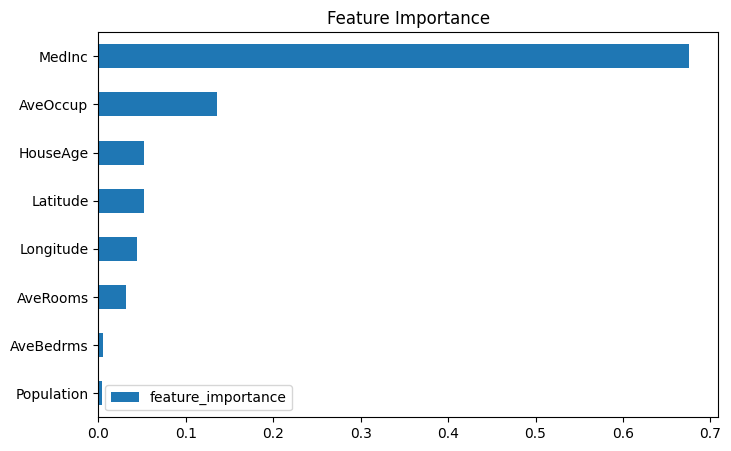

```python
import pandas as pd

# Size of figure (width, height) in inches, ~2.5 cm.
FIGSIZE = (8, 5)

_ = pd.DataFrame({'feature_importance': list(model.stages[1].featureImportances)}, index=FEATURES).sort_values(by='feature_importance').plot.barh(title='Feature Importance', figsize=FIGSIZE)
```

### In-Sample and Out-of-Sample Error

The `transform()` method in all `pyspark.ml` models adds a column called `prediction`. This is different compared to the standard sklearn API.

We see that it does worse on the test dataest. This is to be expected.

```python
residual = F.col('prediction') - F.col(RESPONSE)
metrics = [
    F.mean(F.abs(residual)).alias('mean_absolute_error'),
    F.mean(F.pow(residual, 2)).alias('mean_squared_error'),
    F.stddev_pop(residual).alias('standard_deviation'),
]
```

```python
display(model.transform(train).agg(*metrics))
```

|  | mean_absolute_error | mean_squared_error | standard_deviation |
| --- | --- | --- | --- |
| 0 | 0.432871 | 0.373763 | 0.611361 |

```python
display(model.transform(test).agg(*metrics))
```

|  | mean_absolute_error | mean_squared_error | standard_deviation |
| --- | --- | --- | --- |
| 0 | 0.465268 | 0.429419 | 0.655256 |

### Plot Distribution of Residuals

```python
train_pd = (
    model.transform(train)
    .withColumn(
        'residual',
        F.col('prediction') - F.col(RESPONSE)
    )
    .limit(5000)
    .toPandas()
)
test_pd = (
    model.transform(test)
    .withColumn(
        'residual',
        F.col('prediction') - F.col(RESPONSE)
    )
    .limit(5000)
    .toPandas()
)
```

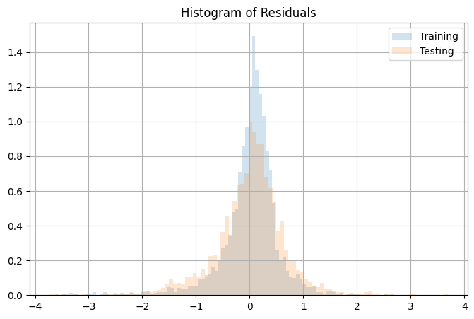

```python
import matplotlib.pyplot as plt

plt.figure(figsize=FIGSIZE)
train_pd['residual'].hist(density=True, alpha=0.2, label='Training', bins=100)
test_pd['residual'].hist(density=True, alpha=0.2, label='Testing', bins=100)
plt.title("Histogram of Residuals")
plt.legend()
plt.show()
```

### Error Analysis

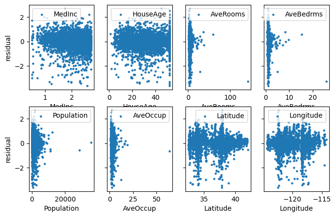

```python
import matplotlib.pyplot as plt
fig, axes = plt.subplots(len(FEATURES) // 3, 4, sharey=True, figsize=FIGSIZE)
for ax, feature in zip(axes.flatten(), FEATURES):
    train_pd.plot.scatter(x=feature, y='residual', marker='.', ax=ax, label=feature)
```

### Saving and Loading Models

When you load your saved models, you need to specify the type of model you are loading back. It is therefore recommended that you always put your transformers/estimators into a Pipeline s.t. all your models can be loaded with a `PipelineModel` and you only need to change the file path to the model.

```python
from pyspark.ml import PipelineModel

# Save the model for later use.
model.write().overwrite().save('/tmp/my_great_model')

# Load the model later.
model = PipelineModel.load('/tmp/my_great_model')
```

# Exercise 5.1.